# Titanic in R!

Doug Barrows

1/16/2019

## Caret (Classification And REgression Training)

- wrapper for [many different ML algorithms](https://rdrr.io/cran/caret/man/models.html)
- allows you to easily try different parameters specific to each algorithm
- integrates resampling methods to select best set of parameters
- provides many defaults so you can use out of box relatively easily, but almost anything can be manually changed
- also allows for imputation of missing values
  - will increase numbers for more accuracy and will be able to compare to real test set (can’t remove NAs from that set)

```r
# install/load caret package
#install.packages("caret")
library(caret)
```

## Resampling - bootstrap vs cross validation

##### caret allows for easy use of strategies to assess model efficiency without having to explicitly separate out a test set of data

[figure not shown]

## Resampling -bootstrap vs cross validation

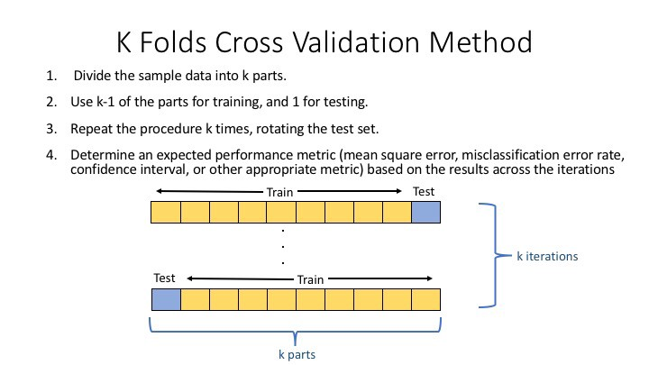

## Load the training data

```r
train <- read.table("./train.csv", sep = ",", header = TRUE)

str(train)
```

```
## 'data.frame':    891 obs. of  12 variables:
##  $ PassengerId: int  1 2 3 4 5 6 7 8 9 10 ...
##  $ Survived   : int  0 1 1 1 0 0 0 0 1 1 ...
##  $ Pclass     : int  3 1 3 1 3 3 1 3 3 2 ...
##  $ Name       : Factor w/ 891 levels "Abbing, Mr. Anthony",..: 109 191 358 277 16 559 520 629 417 581 ...
##  $ Sex        : Factor w/ 2 levels "female","male": 2 1 1 1 2 2 2 2 1 1 ...
##  $ Age        : num  22 38 26 35 35 NA 54 2 27 14 ...
##  $ SibSp      : int  1 1 0 1 0 0 0 3 0 1 ...
##  $ Parch      : int  0 0 0 0 0 0 0 1 2 0 ...
##  $ Ticket     : Factor w/ 681 levels "110152","110413",..: 524 597 670 50 473 276 86 396 345 133 ...
##  $ Fare       : num  7.25 71.28 7.92 53.1 8.05 ...
##  $ Cabin      : Factor w/ 148 levels "","A10","A14",..: 1 83 1 57 1 1 131 1 1 1 ...
##  $ Embarked   : Factor w/ 4 levels "","C","Q","S": 4 2 4 4 4 3 4 4 4 2 ...
```

```r
train$Sex <- as.integer(train$Sex) - 1
```

## How to transform data? What about age?

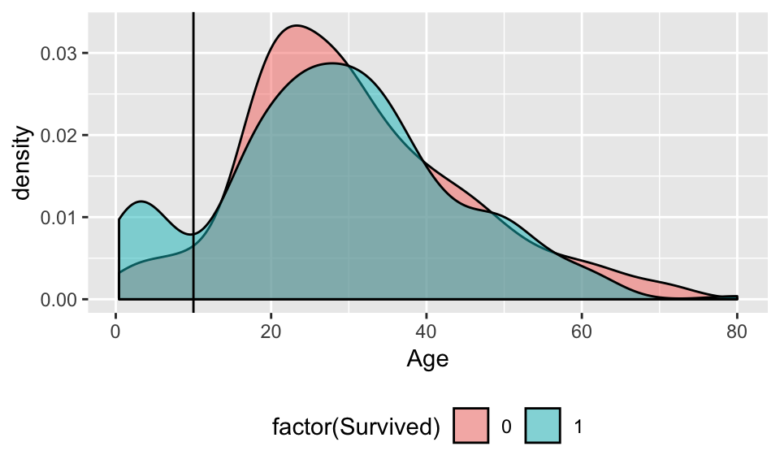

```r
ggplot(train, aes(Age)) +
  geom_density(alpha=0.5, aes(fill=factor(Survived))) +
  geom_vline(xintercept = 10) +
  theme(legend.position = "bottom")
```

```r
train$is_child <- as.integer(train$Age < 10) # make a column specifying child or not
```

## How to transform data? What about age?

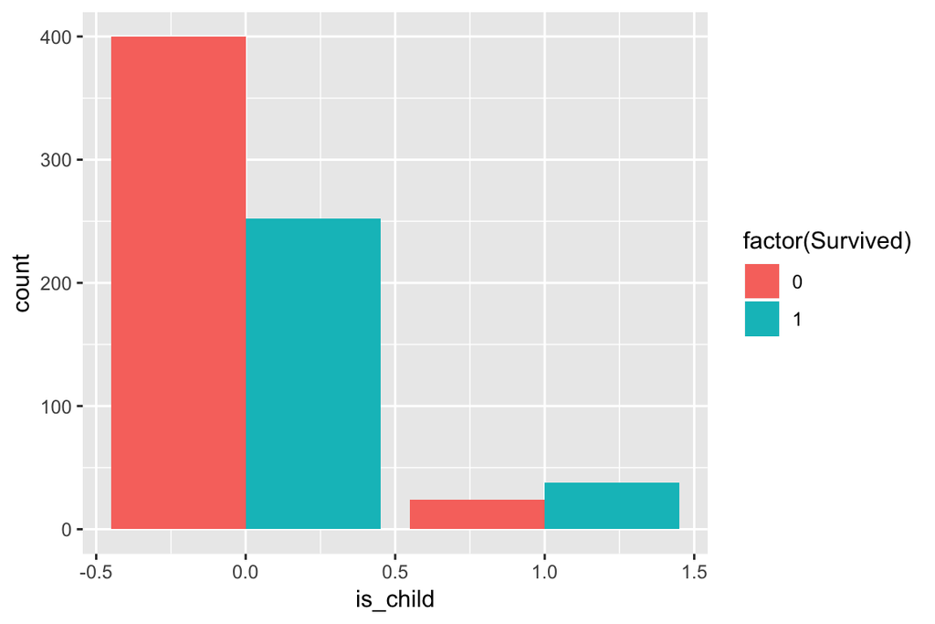

```r
# look specifically whether a child is more likely to survive
ggplot(train, aes(x = is_child, fill=factor(Survived))) +
  geom_bar(position = "dodge")
```

## Transform Fare?

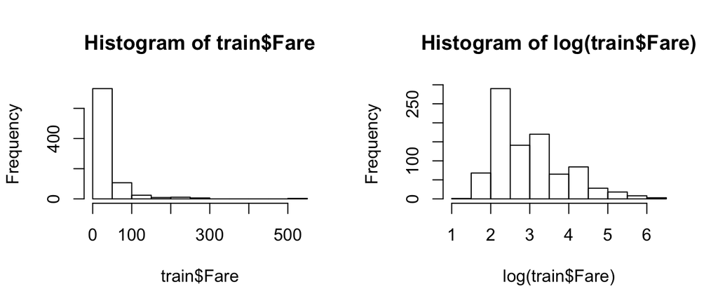

```r
par(mfrow=c(1,2))
hist(train$Fare)
hist(log(train$Fare))
```

```r
train$logfare <- log(train$Fare + 1)
```

## Simplify family size indicators

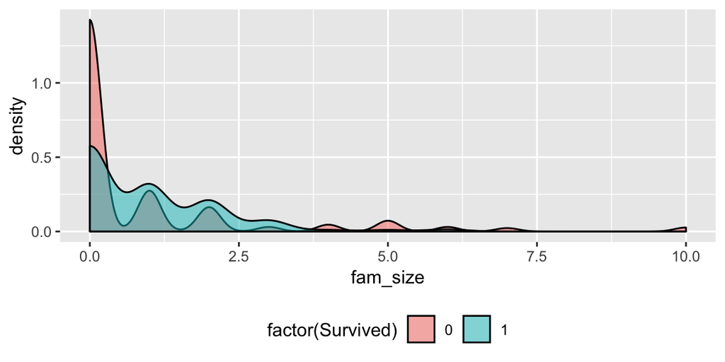

```r
# Sibsp: # of siblings and spouses aboard
# Parch: # of parents and children aboard
train$fam_size <- train$SibSp + train$Parch

#density plot for family size
ggplot(train, aes(fam_size)) +
  geom_density(alpha=0.5, aes(fill=factor(Survived))) +
  theme(legend.position = "bottom")
```

## Simplify family size indicators

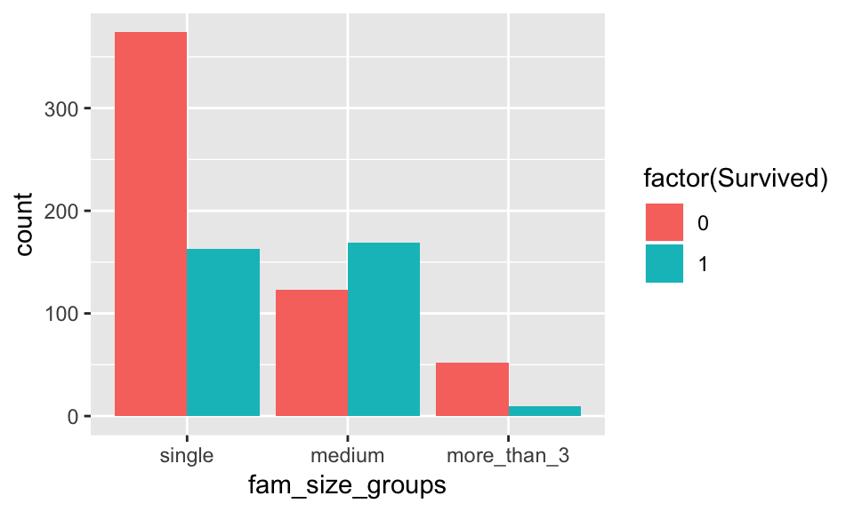

```r
# look at actual survival numbers for different family sizes
train$fam_size_groups <- ordered(ifelse(train$fam_size == 0, "single",
                                        ifelse(train$fam_size > 3, "more_than_3", "medium")),
                                 levels = c("single", "medium", "more_than_3"))
ggplot(train, aes(x = fam_size_groups, fill=factor(Survived))) + geom_bar(position = "dodge")
```

```r
# make columns for both being single and having a big family
train$single <- as.integer(train$fam_size == 0)
train$fam_too_big <- as.integer(train$fam_size > 3)
```

## How do variables correlate with survival?

```r
sub <- c("Survived","Pclass","Sex","Age", "is_child","SibSp", "Parch", "fam_size","single","fam_too_big", "Fare","logfare")
train_sub <- train[colnames(train) %in% sub]
data.frame(SurvivedCorr = cor(na.omit(train_sub))[,1])
```

```
##             SurvivedCorr
## Survived      1.00000000
## Pclass       -0.35965268
## Sex          -0.53882559
## Age          -0.07722109
## SibSp        -0.01735836
## Parch         0.09331701
## Fare          0.26818862
## is_child      0.12981188
## logfare       0.34099999
## fam_size      0.04278705
## single       -0.19614043
## fam_too_big  -0.11864178
```

## Subset features

```r
features3_names <- c("Pclass", "Sex", "logfare", "is_child", "single", "fam_too_big")
features3 <- train[, colnames(train) %in% features3_names]
str(features3)
```

```
## 'data.frame':    891 obs. of  6 variables:
##  $ Pclass     : int  3 1 3 1 3 3 1 3 3 2 ...
##  $ Sex        : num  1 0 0 0 1 1 1 1 0 0 ...
##  $ is_child   : int  0 0 0 0 0 NA 0 1 0 0 ...
##  $ logfare    : num  2.11 4.28 2.19 3.99 2.2 ...
##  $ single     : int  0 0 1 0 1 1 1 0 0 0 ...
##  $ fam_too_big: int  0 0 0 0 0 0 0 1 0 0 ...
```

## Back to caret - set up the training parameters

```r
fitControl <- trainControl(
    method="repeatedcv", # cross-validation (default is bootstrapping)
    number=10, # this will split data set into 10 groups, and continually train on 90% and test on the remaining 10% for all groups
    repeats=5, # repeat the CV 5 times for each model
    verboseIter=TRUE,
    savePredictions = TRUE)
```

## k-nearest neighbor with cross validation

#### fill in NAs with knnImpute

```r
knn_survived_caret_CV3 <- train(features3, # features
                            as.factor(train$Survived), # outcome
                            method = "knn",
                            trControl=fitControl, # use the parameters set previously
                            tuneLength = 12, # this means that caret will choose 12 different values for key parameters
                            preProcess = "knnImpute") # will use KNN to fill in missing values
```

## Look at KNN model

```r
knn_survived_caret_CV3
```

```
## k-Nearest Neighbors
##
## 891 samples
##   6 predictor
##   2 classes: '0', '1'
##
## Pre-processing: nearest neighbor imputation (6), centered (6), scaled (6)
## Resampling: Cross-Validated (10 fold, repeated 5 times)
## Summary of sample sizes: 802, 802, 803, 802, 801, 802, ...
## Resampling results across tuning parameters:
##
##   k   Accuracy   Kappa
##    5  0.8139189  0.6014140
##    7  0.8161661  0.6032224
##    9  0.8208751  0.6128348
##   11  0.8170525  0.6049046
##   13  0.8139238  0.5978846
##   15  0.8193073  0.6075129
##   17  0.8193224  0.6042285
##   19  0.8163782  0.5965606
##   21  0.8215417  0.6055311
##   23  0.8233372  0.6086664
##   25  0.8255768  0.6135497
##   27  0.8208627  0.6046643
##
## Accuracy was used to select the optimal model using the largest value.
## The final value used for the model was k = 25.
```

## Can easily visualize which parameter is best with ggplot and model

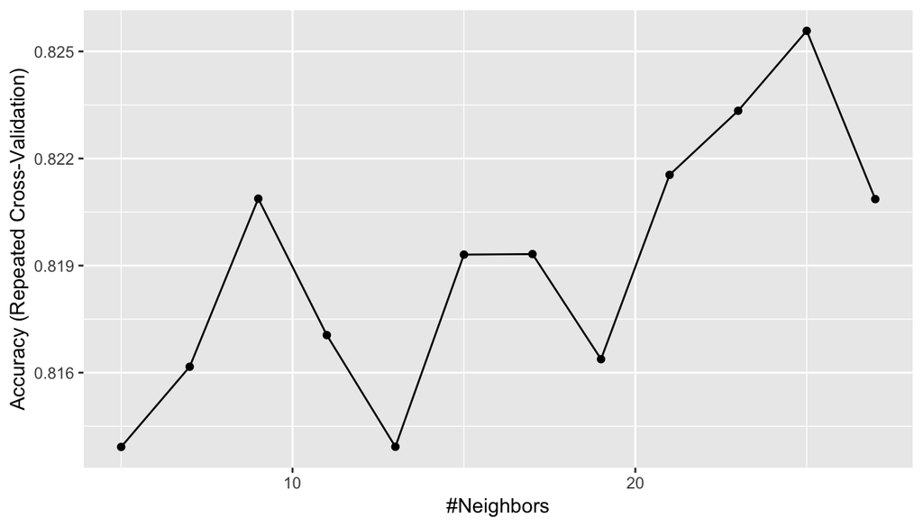

```r
ggplot(knn_survived_caret_CV3)
```

## Logistic Regression

#### Logit function - a “generalized linear model” which allows you to solve classification problems with linear regression

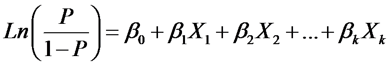

- for every one unit increase in X the log odds will increase by beta, holding all other features constant
  - e.g. beta = 0.67, to get odds from log odds, e^0.67 = 2.
  - this means if beta = 0.67 you would be twice as likely to survive if X = 1 as opposed to X = 0

## Logistic Regression

#### fill NAs with knnImpute

```r
LR_survived_caret_CV3 <- train(features3,
                            as.factor(train$Survived),
                            method = "glm",
                            family = "binomial",
                            trControl=fitControl,
                            preProcess = "knnImpute")
```

## Look at the LR model

```r
LR_survived_caret_CV3$results
```

```
##   parameter  Accuracy     Kappa AccuracySD    KappaSD
## 1      none 0.8089969 0.5887166 0.03380268 0.07399053
```

## Look at the LR model

```r
summary(LR_survived_caret_CV3)
```

```
##
## Call:
## NULL
##
## Deviance Residuals:
##     Min       1Q   Median       3Q      Max
## -3.2215  -0.6281  -0.4247   0.6409   2.5438
##
## Coefficients:
##             Estimate Std. Error z value Pr(>|z|)
## (Intercept) -0.63771    0.09301  -6.856 7.07e-12 ***
## Pclass      -0.59049    0.13883  -4.253 2.11e-05 ***
## Sex         -1.36503    0.09911 -13.773  < 2e-16 ***
## is_child     0.66487    0.12466   5.333 9.64e-08 ***
## logfare      0.38339    0.16422   2.335   0.0196 *
## single       0.11649    0.11697   0.996   0.3193
## fam_too_big -0.80250    0.12448  -6.447 1.14e-10 ***
## ---
## Signif. codes:  0 '***' 0.001 '**' 0.01 '*' 0.05 '.' 0.1 ' ' 1
##
## (Dispersion parameter for binomial family taken to be 1)
##
##     Null deviance: 1186.7  on 890  degrees of freedom
## Residual deviance:  756.6  on 884  degrees of freedom
## AIC: 770.6
##
## Number of Fisher Scoring iterations: 5
```

## Single feature without sex or indicators of wealth

```r
summary(LR_survived_caret_single_test)
```

```
##
## Call:
## NULL
##
## Deviance Residuals:
##     Min       1Q   Median       3Q      Max
## -1.8079  -0.8497  -0.8497   1.1019   2.2076
##
## Coefficients:
##             Estimate Std. Error z value Pr(>|z|)
## (Intercept) -0.49883    0.07336  -6.800 1.05e-11 ***
## is_child     0.34856    0.10528   3.311  0.00093 ***
## single      -0.49615    0.07634  -6.499 8.09e-11 ***
## fam_too_big -0.64296    0.10872  -5.914 3.34e-09 ***
## ---
## Signif. codes:  0 '***' 0.001 '**' 0.01 '*' 0.05 '.' 0.1 ' ' 1
##
## (Dispersion parameter for binomial family taken to be 1)
##
##     Null deviance: 1186.7  on 890  degrees of freedom
## Residual deviance: 1098.8  on 887  degrees of freedom
## AIC: 1106.8
##
## Number of Fisher Scoring iterations: 4
```

## Random Forests!

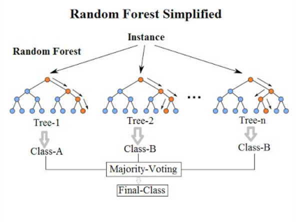

## Random Forests

#### knnImpute to fill NAs

```r
set.seed(1)
rf_survived_caret_CV3_knnimpute <- train(features3,
                            as.factor(train$Survived),
                            method = "rf",
                            ntree = 500, # the number of trees used to make forest
                            trControl=fitControl,
                            tuneGrid = expand.grid(mtry = c(2, 4, 6)),
                            preProcess = "knnImpute")
```

## Look at the RF model

```r
rf_survived_caret_CV3_knnimpute
```

```
## Random Forest
##
## 891 samples
##   6 predictor
##   2 classes: '0', '1'
##
## Pre-processing: nearest neighbor imputation (6), centered (6), scaled (6)
## Resampling: Cross-Validated (10 fold, repeated 5 times)
## Summary of sample sizes: 802, 802, 802, 802, 802, 802, ...
## Resampling results across tuning parameters:
##
##   mtry  Accuracy   Kappa
##   2     0.8292090  0.6242113
##   4     0.8352563  0.6403112
##   6     0.8292013  0.6319169
##
## Accuracy was used to select the optimal model using the largest value.
## The final value used for the model was mtry = 4.
```

## Can also get importance measures for each feature

```r
varImp(rf_survived_caret_CV3_knnimpute, scale = FALSE)
```

```
## rf variable importance
##
##             Overall
## Sex         116.838
## logfare      92.563
## Pclass       37.750
## is_child     20.478
## fam_too_big  17.496
## single        5.829
```

```r
# mean decrease in classification accuracy after permuting that feature over all trees
# i.e. decrease in accuracy in out-of-bag passengers after feature is shuffled
```

## Neural Network - cause why not?

```r
set.seed(1)
nn_survived_caret_CV3_knnimpute <- train(features3,
                            as.factor(train$Survived),
                            method = "nnet",
                            trControl=fitControl,
                            tuneLength = 12,
                            preProcess = "knnImpute")
```

## Look at the NN model

```r
nn_survived_caret_CV3_knnimpute
```

```
## Neural Network
##
## 891 samples
##   6 predictor
##   2 classes: '0', '1'
##
## Pre-processing: nearest neighbor imputation (6), centered (6), scaled (6)
## Resampling: Cross-Validated (10 fold, repeated 5 times)
## Summary of sample sizes: 802, 802, 802, 802, 802, 802, ...
## Resampling results across tuning parameters:
##
##   size  decay         Accuracy   Kappa
##    1    0.0000000000  0.8213512  0.6083857
##    1    0.0001000000  0.8231439  0.6120353
##    1    0.0001995262  0.8179879  0.6020203
```

[output cut: 144 more lines]

## Test data!

#### Transform features in same way as training data

```r
test <- read.delim("./test.csv", sep = ",", header = TRUE)

test$Sex <- as.integer(test$Sex) - 1
test$is_child <- as.integer(test$Age < 10)
test$logfare <- log(test$Fare + 1)
test$fam_size <- test$SibSp + test$Parch
test$single <- as.integer(test$fam_size == 0)
test$fam_too_big <- as.integer(test$fam_size > 3)
```

## subset test data as we did for training data

```r
test_names <- c("Pclass", "Sex", "logfare", "is_child", "single", "fam_too_big")
features3_test <- test[, colnames(test) %in% test_names]
str(features3_test)
```

```
## 'data.frame':    418 obs. of  6 variables:
##  $ Pclass     : int  3 3 2 3 3 3 3 2 3 3 ...
##  $ Sex        : num  1 0 1 1 0 1 0 1 0 1 ...
##  $ is_child   : int  0 0 0 0 0 0 0 0 0 0 ...
##  $ logfare    : num  2.18 2.08 2.37 2.27 2.59 ...
##  $ single     : int  1 0 1 1 0 1 1 0 1 0 ...
##  $ fam_too_big: int  0 0 0 0 0 0 0 0 0 0 ...
```

```r
str(features3)
```

```
## 'data.frame':    891 obs. of  6 variables:
##  $ Pclass     : int  3 1 3 1 3 3 1 3 3 2 ...
##  $ Sex        : num  1 0 0 0 1 1 1 1 0 0 ...
##  $ is_child   : int  0 0 0 0 0 NA 0 1 0 0 ...
##  $ logfare    : num  2.11 4.28 2.19 3.99 2.2 ...
##  $ single     : int  0 0 1 0 1 1 1 0 0 0 ...
##  $ fam_too_big: int  0 0 0 0 0 0 0 1 0 0 ...
```

## output data frames to be used for scoring

```r
# predict knn cross validation2
predictions_test_submit_knnCV3 <- data.frame(PassengerId = test$PassengerId, Survived = predict(knn_survived_caret_CV3, features3_test))
head(predictions_test_submit_knnCV3)
```

```
##   PassengerId Survived
## 1         892        0
## 2         893        0
## 3         894        0
## 4         895        0
## 5         896        0
## 6         897        0
```

```r
#write.table(predictions_test_submit_knnCV3, "./test_knn_CV_fam.csv", sep = ",", row.names = FALSE)

## logistic regression - features set3 - knnimpute
predictions_test_submit_LR_CV3 <- data.frame(PassengerId = test$PassengerId, Survived = predict(LR_survived_caret_CV3, features3_test))
#write.table(predictions_test_submit_LR_CV3, "./test_LR_CV_features3_fam_knnimpute.csv", sep = ",", row.names = FALSE)

# predict rf cross validation knnimpute
predictions_test_submit_rf_CV3_knnimpute <- data.frame(PassengerId = test$PassengerId, Survived = predict(rf_survived_caret_CV3_knnimpute, features3_test))
#write.table(predictions_test_submit_rf_CV3_knnimpute, "./test_rf_CV3_fam_knnimpute.csv", sep = ",", row.names = FALSE)

# predict nn cross validation knnimpute
predictions_test_submit_nn_CV3_knnimpute <- data.frame(PassengerId = test$PassengerId, Survived = predict(nn_survived_caret_CV3_knnimpute, features3_test))
#write.table(predictions_test_submit_nn_CV3_knnimpute, "./test_nn_CV3_fam_knnimpute.csv", sep = ",", row.names = FALSE)
```

## How did we do?

```r
algorithms <- c("KNN", "Logistic Regression", "Random Forest", "Neural Network")
accuracy <- c(max(knn_survived_caret_CV3$results$Accuracy),
                max(LR_survived_caret_CV3$results$Accuracy),
                max(rf_survived_caret_CV3_knnimpute$results$Accuracy),
                max(nn_survived_caret_CV3_knnimpute$results$Accuracy))

kaggle_transformed <- c(0.7655, 0.7703, 0.8038, 0.7703)

data.frame(row.names = algorithms,
           accuracy,
           kaggle_transformed)
```

```
##                      accuracy kaggle_transformed
## KNN                 0.8255768             0.7655
## Logistic Regression 0.8089969             0.7703
## Random Forest       0.8352563             0.8038
## Neural Network      0.8334837             0.7703
```

## Is this better than untransformed features?

#### redid the above modeling with these features…

```r
features_NT_names <- c("Pclass", "Sex", "Age", "SibSp", "Parch", "Fare")
features_NT <- train[, colnames(train) %in% features_NT_names]
str(features_NT)
```

```
## 'data.frame':    891 obs. of  6 variables:
##  $ Pclass: int  3 1 3 1 3 3 1 3 3 2 ...
##  $ Sex   : num  1 0 0 0 1 1 1 1 0 0 ...
##  $ Age   : num  22 38 26 35 35 NA 54 2 27 14 ...
##  $ SibSp : int  1 1 0 1 0 0 0 3 0 1 ...
##  $ Parch : int  0 0 0 0 0 0 0 1 2 0 ...
##  $ Fare  : num  7.25 71.28 7.92 53.1 8.05 ...
```

## Is this better than untransformed features?

```r
kaggle_nontransformed <- c(0.7703, 0.7519, 0.7560, 0.7512)
data.frame(row.names = algorithms,
           kaggle_transformed,
           kaggle_nontransformed)
```

```
##                     kaggle_transformed kaggle_nontransformed
## KNN                             0.7655                0.7703
## Logistic Regression             0.7703                0.7519
## Random Forest                   0.8038                0.7560
## Neural Network                  0.7703                0.7512
```